| [GitHub](https://github.com/Arize-ai/phoenix) |

# Q&A Correctness Evals

The purpose of this notebook is:

- to evaluate the performance of an LLM-assisted approach to detecting issues with Q&A systems on retrieved context data
- to provide an experimental framework for users to iterate and improve on the default classification template.

## Install Dependencies and Import Libraries

```python
#####################
## N_EVAL_SAMPLE_SIZE
#####################

N_EVAL_SAMPLE_SIZE = 96 # limited currently
```

```python
!pip install -qq "arize-phoenix-evals" "openai>=1" ipython matplotlib pycm scikit-learn tiktoken nest_asyncio
```

ℹ️ To enable async request submission in notebook environments like Jupyter or Google Colab, optionally use `nest_asyncio`. `nest_asyncio` globally patches `asyncio` to enable event loops to be re-entrant. This is not required for non-notebook environments.

Without `nest_asyncio`, eval submission can be much slower, depending on your organization's rate limits. Speed increases of about 5x are typical.

```python
import os
from getpass import getpass
from rouge_score import rouge_scorer
import matplotlib.pyplot as plt
import openai
import pandas as pd
from transformers import GPT2Tokenizer, GPT2LMHeadModel
import torch
import nltk
from nltk.translate.bleu_score import sentence_bleu
import warnings
warnings.filterwarnings('ignore')

import nest_asyncio

nest_asyncio.apply()
```

```python
from phoenix.evals import (
    QA_PROMPT_RAILS_MAP,
    QA_PROMPT_TEMPLATE,

    HALLUCINATION_PROMPT_RAILS_MAP,
    HALLUCINATION_PROMPT_TEMPLATE,

    TOXICITY_PROMPT_RAILS_MAP,
    TOXICITY_PROMPT_TEMPLATE,

    RAG_RELEVANCY_PROMPT_RAILS_MAP,
    RAG_RELEVANCY_PROMPT_TEMPLATE,

    OpenAIModel, # the benchmark model.
    download_benchmark_dataset,
    llm_classify,
)
from pycm import ConfusionMatrix
from sklearn.metrics import classification_report

pd.set_option("display.max_colwidth", None)
```

## Download the Dataset

- Squad 2: The 2.0 version of the large-scale dataset Stanford Question Answering Dataset (SQuAD 2.0) allows researchers to design AI models for reading comprehension tasks under challenging constraints. https://web.stanford.edu/class/archive/cs/cs224n/cs224n.1194/reports/default/15785042.pdf
- Supplemental Data to Sqaud 2: In order to check the case of detecting incorrect answers, we created wrong answers based on the context data. The wrong answers are intermixed with right answers.
- sampled_answer is a sampled column of randomly original Squad 2 or incorrect answers

```python
df_ben = download_benchmark_dataset(task="qa-classification", dataset_name="qa_generated_dataset")
```

```python
df_ben.shape
```

```
(2500, 9)
```

```python
os.listdir('./data')
```

```
['Testing Reg B Testing Bank TrueFalse_v2.xlsx',
 'Testing Reg B Testing Bank TF v5.xlsx',
 'Testing Reg B Testing Bank TrueFalse.xlsx',
 'Testing Reg B Testing Bank TF v4.xlsx',
 'Testing Reg B Testing Bank TrueFalse_v3.xlsx',
 'Testing_Bank_Reg_B_QA_Correctness_v6.xlsx',
 'Testing Reg B Testing Bank TrueFalse.csv',
 'Testing_Bank_Reg_B_QA_Correctness_v5.xlsx',
 '.ipynb_checkpoints',
 'testing_bank_reg_b_question_responses_chnk_df.csv',
 'Testing_Bank_Reg_B_QA_Correctness_v5 - Sheet1.csv',
 'Testing Reg B Testing Bank TF v6.xlsx']
```

```python
file_name =  'testing_bank_reg_b_question_responses_chnk_df.csv'
```

```python
# for chunking_technique in ['smt_chnk', 'nve_chnk']:

#   print ('testing chunking techniqe,' + chunking_technique)

#   for file_to_test in ['./data/reg_b_pdf_text.txt', './data/reg_b_web_print_text.txt']:
```

# Data path and key data dictionary

```python
data_path= './data/Testing_Bank_Reg_B_QA_Correctness_v6.xlsx'

data_path = r'./data/{}'.format(file_name)
data_path
```

```
'./data/testing_bank_reg_b_question_responses_chnk_df.csv'
```

```python
# df=pd.read_csv(data_path)
```

```python
df=pd.read_csv(data_path)
```

```python
df.head()
```

|  | Unnamed: 0 | # | title | context.span_id | question | ground_truth | context | answer_true_flag | answer_true | is_hallucination | ... | ref1_smt_chnk_regB_WebTxt | ref2_smt_chnk_regB_WebTxt | question_nve_chnk_regB_PdfTxt | answer_nve_chnk_regB_PdfTxt | ref1_nve_chnk_regB_PdfTxt | ref2_nve_chnk_regB_PdfTxt | question_nve_chnk_regB_WebTxt | answer_nve_chnk_regB_WebTxt | ref1_nve_chnk_regB_WebTxt | ref2_nve_chnk_regB_WebTxt |
| --- | --- | --- | --- | --- | --- | --- | --- | --- | --- | --- | --- | --- | --- | --- | --- | --- | --- | --- | --- | --- | --- |
| 0 | 0 | 1 | reg b | 5420b5dc5061d0b7 | How can a financial institution annualize the number of covered credit transactions it originates to small businesses from October 1 through December 31, 2023? | A financial institution can annualize the number of covered credit transactions it originates to small businesses from October 1 through December 31, 2023 by quadrupling the originations for this peri… | The financial institution may annualize the number of covered credit transactions it originates to small\nbusinesses from October 1 through December 31, 2023 by quadrupling the originations for this p… | 1 | True | NaN | ... | Step 7. Examiners should consult with their agency’s\nsupervisory staff if they see a need to contact control group\nor prohibited basis group applicants to substantiate the\nsteering analysis.\nF. Tr… | Additionally, consideration should be limited\nto factors which examiners determine to be legitimate.\nWhile the period for review should be 12-months, prohibited\nbasis group and control group borrow… | How can a financial institution annualize the number of covered credit transactions it originates to small businesses from October 1 through December 31, 2023? | To annualize the number of covered credit transactions a financial institution originates to small businesses from October 1 through December 31, 2023, the institution should calculate the total numbe… | Step 7. Examiners should consult with their agency’s\nsupervisory staff if they see a need to contact control group\nor prohibited basis group applicants to substantiate the\nsteering analysis.\nF. Tr… | Additionally, consideration should be limited\nto factors which examiners determine to be legitimate.\nWhile the period for review should be 12-months, prohibited\nbasis group and control group borrow… | How can a financial institution annualize the number of covered credit transactions it originates to small businesses from October 1 through December 31, 2023? | To annualize the number of covered credit transactions a financial institution originates to small businesses from October 1 through December 31, 2023, the institution should calculate the total numbe… | Step 7. Examiners should consult with their agency’s\nsupervisory staff if they see a need to contact control group\nor prohibited basis group applicants to substantiate the\nsteering analysis.\nF. Tr… | Additionally, consideration should be limited\nto factors which examiners determine to be legitimate.\nWhile the period for review should be 12-months, prohibited\nbasis group and control group borrow… |
| 1 | 1 | 2 | reg b | ab727ae68cc856ac | What options does an applicant have if they want a statement of specific reasons for adverse action taken by a creditor within 60 days of notification? | The applicant has the option to request the statement of specific reasons for adverse action taken by the creditor in writing within 60 days of receiving the creditor's notification. | The disclosure shall include the name, address, and\ntelephone number of the person or office from which the statement of reasons can be obtained. If the creditor\nchooses to provide the reasons orall… | 1 | True | NaN | ... | c. How and when the policy or communication was put\ninto effect.\nd. How widely the policy or communication was applied.\ne. Whether and to what extent applicants were adversely\naffected by the poli… | Document all responses that have been provided\nby the institution, not just its “best” or “final” response.\nDocument each discussion with dates, names, titles,\nquestions, responses, any information… | What options does an applicant have if they want a statement of specific reasons for adverse action taken by a creditor within 60 days of notification? | An applicant has the option to request a statement of specific reasons for adverse action taken by a creditor within 60 days of notification. | c. How and when the policy or communication was put\ninto effect.\nd. How widely the policy or communication was applied.\ne. Whether and to what extent applicants were adversely\naffected by the poli… | Document all responses that have been provided\nby the institution, not just its “best” or “final” response.\nDocument each discussion with dates, names, titles,\nquestions, responses, any information… | What options does an applicant have if they want a statement of specific reasons for adverse action taken by a creditor within 60 days of notification? | An applicant has the option to request a statement of specific reasons for adverse action taken by a creditor within 60 days of notification. | c. How and when the policy or communication was put\ninto effect.\nd. How widely the policy or communication was applied.\ne. Whether and to what extent applicants were adversely\naffected by the poli… | Document all responses that have been provided\nby the institution, not just its “best” or “final” response.\nDocument each discussion with dates, names, titles,\nquestions, responses, any information… |
| 2 | 2 | 3 | reg b | 68bfeb197b24577d | What specific information about a financial institution's parent entity must be included in the submission? | The specific information about a financial institution's parent entity that must be included in the submission are the name of the immediate parent entity, the Legal Entity Identifier (LEI) of the imm… | (b) Financial institution identifying information. A financial institution shall provide each of the following with its submission:\n(1) Its name.\n(2) Its headquarters address.\n(3) The name and busi… | 1 | True | NaN | ... | Examples of terms and features include\nprepayment penalties and escrow requirements. The\ndistinction between a product, term, and feature may\nvary institution to institution. For example, some\nins… | This will help\nexaminers to recognize the potential scope of policybased violations.\n• The portfolio consists of applications from a purchased\ninstitution. If so, for scoping purposes, examiners\ns… | What specific information about a financial institution's parent entity must be included in the submission? | Information regarding an affiliate or holding company subsidiary should be obtained directly from the institution itself. | Examples of terms and features include\nprepayment penalties and escrow requirements. The\ndistinction between a product, term, and feature may\nvary institution to institution. For example, some\nins… | This will help\nexaminers to recognize the potential scope of policybased violations.\n• The portfolio consists of applications from a purchased\ninstitution. If so, for scoping purposes, examiners\ns… | What specific information about a financial institution's parent entity must be included in the submission? | Information regarding an affiliate or holding company subsidiary should be obtained directly from the institution itself. | Examples of terms and features include\nprepayment penalties and escrow requirements. The\ndistinction between a product, term, and feature may\nvary institution to institution. For example, some\nins… | This will help\nexaminers to recognize the potential scope of policybased violations.\n• The portfolio consists of applications from a purchased\ninstitution. If so, for scoping purposes, examiners\ns… |
| 3 | 3 | 4 | reg b | 6e6673e2fb94d5eb | What are some examples of appropriate corrective actions that may be taken based on the results of a self-test for potential violations of the Equal Credit Opportunity Act? | Examples of appropriate corrective actions that may be taken based on the results of a self-test for potential violations of the Equal Credit Opportunity Act include offering to extend credit to indiv… | In\ndetermining whether it is more likely than not that a violation occurred, a creditor must treat testers as if they are actual applicants for\ncredit. A creditor may not refuse to take appropriate … | 1 | True | NaN | ... | IV. Fair Lending — Fair Lending Laws and Regulations\nFDIC Consumer Compliance Examination Manual – March 2021 IV – 1.1\nFair Lending Laws and Regulations\nIntroduction\nThis overview provides a basic… | Document all responses that have been provided\nby the institution, not just its “best” or “final” response.\nDocument each discussion with dates, names, titles,\nquestions, responses, any information… | What are some examples of appropriate corrective actions that may be taken based on the results of a self-test for potential violations of the Equal Credit Opportunity Act? | Examples of appropriate corrective actions that may be taken based on the results of a self-test for potential violations of the Equal Credit Opportunity Act include providing additional training to s… | IV. Fair Lending — Fair Lending Laws and Regulations\nFDIC Consumer Compliance Examination Manual – March 2021 IV – 1.1\nFair Lending Laws and Regulations\nIntroduction\nThis overview provides a basic… | Document all responses that have been provided\nby the institution, not just its “best” or “final” response.\nDocument each discussion with dates, names, titles,\nquestions, responses, any information… | What are some examples of appropriate corrective actions that may be taken based on the results of a self-test for potential violations of the Equal Credit Opportunity Act? | Examples of appropriate corrective actions that may be taken based on the results of a self-test for potential violations of the Equal Credit Opportunity Act include providing additional training to s… | IV. Fair Lending — Fair Lending Laws and Regulations\nFDIC Consumer Compliance Examination Manual – March 2021 IV – 1.1\nFair Lending Laws and Regulations\nIntroduction\nThis overview provides a basic… | Document all responses that have been provided\nby the institution, not just its “best” or “final” response.\nDocument each discussion with dates, names, titles,\nquestions, responses, any information… |
| 4 | 4 | 5 | reg b | c50465abd93a6b24 | What does a financial institution report as the credit purpose if the applicant does not provide any information regarding the purpose of the credit? | The financial institution reports the credit purpose as "not provided by applicant and otherwise undetermined" if the applicant does not provide any information regarding the purpose of the credit. | If an application has more than three purposes, the financial institution reports any three of those purposes. In the example\nabove, if the funds were also used to purchase equipment, the financial i… | 1 | True | NaN | ... | This will help\nexaminers to recognize the potential scope of policybased violations.\n• The portfolio consists of applications from a purchased\ninstitution. If so, for scoping purposes, examiners\ns… | I. Credit Scoring.\nIf the scoping process results in the selection of a focal point\nthat includes a credit or mortgage scored loan product, refer\nto the Considering Automated Underwriting and Credi… | What does a financial institution report as the credit purpose if the applicant does not provide any information regarding the purpose of the credit? | The financial institution typically reports the credit purpose as "not available" if the applicant does not provide any information regarding the purpose of the credit. | This will help\nexaminers to recognize the potential scope of policybased violations.\n• The portfolio consists of applications from a purchased\ninstitution. If so, for scoping purposes, examiners\ns… | I. Credit Scoring.\nIf the scoping process results in the selection of a focal point\nthat includes a credit or mortgage scored loan product, refer\nto the Considering Automated Underwriting and Credi… | What does a financial institution report as the credit purpose if the applicant does not provide any information regarding the purpose of the credit? | The financial institution would report the credit purpose as "not available" if the applicant does not provide any information regarding the purpose of the credit. | I. Credit Scoring.\nIf the scoping process results in the selection of a focal point\nthat includes a credit or mortgage scored loan product, refer\nto the Considering Automated Underwriting and Credi… | This will help\nexaminers to recognize the potential scope of policybased violations.\n• The portfolio consists of applications from a purchased\ninstitution. If so, for scoping purposes, examiners\ns… |

5 rows × 26 columns

```python
# !pip install torchvision
```

```python
# !pip install transformers nltk
```

```python
# !pip3 install torch torchvision
```

```python
# Make sure to download the necessary NLTK data
nltk.download('punkt')
```

```
True
```

```python
def calculate_bleu(reference, hypothesis):
    reference = nltk.word_tokenize(reference)
    hypothesis = nltk.word_tokenize(hypothesis)
    score = sentence_bleu([reference], hypothesis)
    return round(score, 4)

# Initialize tokenizer and model for perplexity calculation
tokenizer = GPT2Tokenizer.from_pretrained("gpt2")
model = GPT2LMHeadModel.from_pretrained("gpt2")

def calculate_perplexity(sentence):
    inputs = tokenizer(sentence, return_tensors='pt')
    with torch.no_grad():
        outputs = model(**inputs, labels=inputs["input_ids"])
        loss = outputs.loss
        perplexity = torch.exp(loss)
    return round(perplexity.item(), 4)



scorer = rouge_scorer.RougeScorer(['rouge1', 'rouge2', 'rougeL'], use_stemmer=True)

def calculate_rouge(reference, hypothesis):
    scores = scorer.score(reference, hypothesis)
    rouge1 = round(scores['rouge1'].fmeasure, 4)
    rouge2 = round(scores['rouge2'].fmeasure, 4)
    rougeL_fmeasure = round(scores['rougeL'].fmeasure, 4) #  ROUGE-L specifically measures the Longest Common Subsequence (LCS)
                                                                   #between a reference text and a generated text. Here's a brief overview of what it entails:
    rougeL_precision = round(scores['rougeL'].precision, 4)
    rougeL_recall = round(scores['rougeL'].recall, 4)
    return rouge1, rouge2, (rougeL_fmeasure, rougeL_precision, rougeL_recall)

# Precision, Recall, and F-measure:
# Precision: The number of words in the LCS divided by the total number of words in the candidate summary.
# Recall: The number of words in the LCS divided by the total number of words in the reference summary.
# F-measure: The harmonic mean of Precision and Recall.
```

```python
# !pip install rouge-score
```

```python
ans_col_name=[col for col in df.columns if 'answer_' in col and col[-3:] =='Txt']
ans_col_name
```

```
['answer_smt_chnk_regB_PdfTxt',
 'answer_smt_chnk_regB_WebTxt',
 'answer_nve_chnk_regB_PdfTxt',
 'answer_nve_chnk_regB_WebTxt']
```

```python
ground_truth_col='ground_truth'
sampled_answer_to_test_col = ans_col_name[0]


ground_truth = df[ground_truth_col].tolist()
sampled_answer_to_test = df[ans_col_name[0]].tolist()
sampled_answer_to_test_2 = df[ans_col_name[1]].tolist()

context = df['context'].tolist()
```

```python
# BLEU
bleu_scores = [calculate_bleu(ref, hyp) for ref, hyp in zip(ground_truth, sampled_answer_to_test)]
df['bleu_score'] = bleu_scores
```

```python
# #  perplexity for texts in columns
# perplexities = [calculate_perplexity(text) for text in ground_truth]
# df['perplexity_g'] = perplexities
# perplexities = [calculate_perplexity(text) for text in sampled_answer_to_test]

# df['perplexity_sample']=perplexities
```

```python
# perplexities = [calculate_perplexity(text) for text in context ]

# df['perplexity_context']=perplexities
```

```python
# Calculate ROUGE scores for each pair of texts
rouge_scores = [calculate_rouge(ref, hyp) for ref, hyp in zip(ground_truth, sampled_answer_to_test)]
rouge1_scores, rouge2_scores, rougeL_scores = zip(*rouge_scores)
rougeL_fmeasure, rougeL_precision, rougeL_recall = zip(*rougeL_scores)

df['rouge1'] = rouge1_scores
df['rouge2'] = rouge2_scores
df['rougeL_fmeasure'] = rougeL_fmeasure
df['rougeL_precision'] = rougeL_precision
df['rougeL_recall'] = rougeL_recall
```

```python
df_rouge2=df.copy()
# Calculate ROUGE scores for each pair of texts
rouge_scores = [calculate_rouge(ref, hyp) for ref, hyp in zip(ground_truth, sampled_answer_to_test_2)]
rouge1_scores, rouge2_scores, rougeL_scores = zip(*rouge_scores)
rougeL_fmeasure, rougeL_precision, rougeL_recall = zip(*rougeL_scores)

df_rouge2['rouge1'] = rouge1_scores
df_rouge2['rouge2'] = rouge2_scores
df_rouge2['rougeL_fmeasure'] = rougeL_fmeasure
df_rouge2['rougeL_precision'] = rougeL_precision
df_rouge2['rougeL_recall'] = rougeL_recall

# BLEU
bleu_scores = [calculate_bleu(ref, hyp) for ref, hyp in zip(ground_truth, sampled_answer_to_test_2)]
df_rouge2['bleu_score'] = bleu_scores
```

```python
df.mean().reset_index().rename(columns= {'index':'Columns', 0:'Means_{}'.format(ans_col_nanme[0])})
```

|  | Columns | Means_answer_smt_chnk_regB_PdfTxt |
| --- | --- | --- |
| 0 | Unnamed: 0 | 47.500000 |
| 1 | # | 48.500000 |
| 2 | answer_true_flag | 1.000000 |
| 3 | answer_true | 1.000000 |
| 4 | is_hallucination | NaN |
| 5 | bleu_score | 0.238879 |
| 6 | rouge1 | 0.485484 |
| 7 | rouge2 | 0.310819 |
| 8 | rougeL_fmeasure | 0.394098 |
| 9 | rougeL_precision | 0.412349 |
| 10 | rougeL_recall | 0.416927 |

```python
df_rouge2.mean().reset_index().rename(columns= {'index':'Columns', 0:'Means_{}'.format(ans_col_nanme[1])})
```

|  | Columns | Means_answer_smt_chnk_regB_WebTxt |
| --- | --- | --- |
| 0 | Unnamed: 0 | 47.500000 |
| 1 | # | 48.500000 |
| 2 | answer_true_flag | 1.000000 |
| 3 | answer_true | 1.000000 |
| 4 | is_hallucination | NaN |
| 5 | bleu_score | 0.240764 |
| 6 | rouge1 | 0.479701 |
| 7 | rouge2 | 0.309931 |
| 8 | rougeL_fmeasure | 0.392265 |
| 9 | rougeL_precision | 0.412146 |
| 10 | rougeL_recall | 0.415077 |

```python
!pip install tqdm
```

```python
from tqdm import tqdm


ground_truth_col='ground_truth'
sampled_answer_to_test_col = ans_col_nanme[0]


ground_truth = df[ground_truth_col].tolist()
sampled_answer_to_test = df[ans_col_nanme[0]].tolist()
sampled_answer_to_test_2 = df[ans_col_nanme[1]].tolist()

# context = df['context'].tolist()

blue_rouge_metrics=pd.DataFrame({'Metrics':['bleu_score','rouge1','rouge2','rougeL_fmeasure','rouge_precision','rouge_recall' ]})

for sampled_answer_to_test_col in tqdm(ans_col_nanme):
    print(sampled_answer_to_test_col)

    # initial df
    blue_rouge= df[[ground_truth_col, sampled_answer_to_test_col]].copy()

    # values for calculations
    ground_truth = blue_rouge[ground_truth_col].tolist()
    sampled_answer_to_test = blue_rouge[sampled_answer_to_test_col].tolist()

    # BLEU
    bleu_scores = [calculate_bleu(ref, hyp) for ref, hyp in zip(ground_truth, sampled_answer_to_test)]
    blue_rouge['bleu_score'] = bleu_scores

    # Calculate ROUGE scores for each pair of texts
    rouge_scores = [calculate_rouge(ref, hyp) for ref, hyp in zip(ground_truth, sampled_answer_to_test)]
    rouge1_scores, rouge2_scores, rougeL_scores = zip(*rouge_scores)
    rougeL_fmeasure, rougeL_precision, rougeL_recall = zip(*rougeL_scores)

    blue_rouge['rouge1'] = rouge1_scores
    blue_rouge['rouge2'] = rouge2_scores
    blue_rouge['rougeL_fmeasure'] = rougeL_fmeasure
    blue_rouge['rougeL_precision'] = rougeL_precision
    blue_rouge['rougeL_recall'] = rougeL_recall

    blue_rouge_metrics_temp = blue_rouge.mean().reset_index().rename(columns= {'index':'Columns', 0:'Means_{}'.format(sampled_answer_to_test_col)})

    blue_rouge_metrics=pd.concat([blue_rouge_metrics,blue_rouge_metrics_temp[['Means_{}'.format(sampled_answer_to_test_col)]]], axis=1)
```

```
answer_smt_chnk_regB_PdfTxt
```

```
answer_smt_chnk_regB_WebTxt
answer_nve_chnk_regB_PdfTxt
```

```
answer_nve_chnk_regB_WebTxt
```

```python
blue_rouge_metrics
```

|  | Metrics | Means_answer_smt_chnk_regB_PdfTxt | Means_answer_smt_chnk_regB_WebTxt | Means_answer_nve_chnk_regB_PdfTxt | Means_answer_nve_chnk_regB_WebTxt |
| --- | --- | --- | --- | --- | --- |
| 0 | bleu_score | 0.238879 | 0.240764 | 0.230133 | 0.232504 |
| 1 | rouge1 | 0.485484 | 0.479701 | 0.470359 | 0.474082 |
| 2 | rouge2 | 0.310819 | 0.309931 | 0.302605 | 0.309088 |
| 3 | rougeL_fmeasure | 0.394098 | 0.392265 | 0.382977 | 0.386097 |
| 4 | rouge_precision | 0.412349 | 0.412146 | 0.407342 | 0.415234 |
| 5 | rouge_recall | 0.416927 | 0.415077 | 0.404200 | 0.405688 |

```python
# df.groupby('is_hallucination').mean()
```

```python
# df_rouge2.groupby('is_hallucination').mean()
```

```python
# df.groupby(['is_hallucination','Difficulty Level').mean()
```

## Display Binary Q&A Classification Template

View the default template used to classify hallucinations. You can tweak this template and evaluate its performance relative to the default.

```python
print(QA_PROMPT_TEMPLATE)
```

```
You are given a question, an answer and reference text. You must determine whether the
given answer correctly answers the question based on the reference text. Here is the data:
    [BEGIN DATA]
    ************
    [Question]: {input}
    ************
    [Reference]: {reference}
    ************
    [Answer]: {output}
    [END DATA]
Your response must be a single word, either "correct" or "incorrect",
and should not contain any text or characters aside from that word.
"correct" means that the question is correctly and fully answered by the answer.
"incorrect" means that the question is not correctly or only partially answered by the
answer.
```

## Configure the API Key

Configure your OpenAI API key.

```python
if not (openai_api_key := os.getenv("OPENAI_API_KEY")):
    openai_api_key = getpass("🔑 Enter your OpenAI API key: ")
openai.api_key = openai_api_key
os.environ["OPENAI_API_KEY"] = openai_api_key
```

## LLM Evals: Q&A Classifications GPT-3.5

Evaluate the predictions against human-labeled ground-truth Q&A labels.

```python
model = OpenAIModel(model="gpt-3.5-turbo", temperature=0.0, request_timeout=20)
```

# Testing

```python
ans_col_name=[col for col in df.columns if 'answer_' in col and col[-3:] =='Txt']
ans_col_name
```

```
['answer_smt_chnk_regB_PdfTxt',
 'answer_smt_chnk_regB_WebTxt',
 'answer_nve_chnk_regB_PdfTxt',
 'answer_nve_chnk_regB_WebTxt']
```

```python
df_sample.head()
```

[output not shown]

5 rows × 30 columns

Instantiate the LLM and set parameters.

### skiping gpt 4

```python
model = OpenAIModel(
    model="gpt-4",
    temperature=0.0,
)
```

```python
model("Hello world, this is a test if you are working?")
```

```
"Hello! I'm working perfectly. How can I assist you today?"
```

Run LLM Eval using the template against the dataset: This is the main Eval function

### testing

```python
# The rails force the output to specific values of the template
# It will remove text such as ",,," or "...", anything not the
# binary value expected from the template
rails = list(QA_PROMPT_RAILS_MAP.values())
Q_and_A_classifications = llm_classify(
    dataframe=df_sample,
    template=QA_PROMPT_TEMPLATE,
    model=model,
    rails=rails,
    concurrency=20,
)["label"].tolist()
```

```
llm_classify |          | 0/96 (0.0%) | ⏳ 00:00<? | ?it/s
```

[output not shown]

```python
df_sample.head(10)
```

|  | Unnamed: 0 | # | title | context.span_id | input | ground_truth | reference | answer_true_flag | answer_true | is_hallucination | ... | question_nve_chnk_regB_WebTxt | answer_nve_chnk_regB_WebTxt | ref1_nve_chnk_regB_WebTxt | ref2_nve_chnk_regB_WebTxt | bleu_score | rouge1 | rouge2 | rougeL_fmeasure | rougeL_precision | rougeL_recall |
| --- | --- | --- | --- | --- | --- | --- | --- | --- | --- | --- | --- | --- | --- | --- | --- | --- | --- | --- | --- | --- | --- |
| 0 | 62 | 63 | reg b | 0081b8ac5b1fad77 | How does the flexibility for financial institutions to design their own procedures impact the collection of applicant-provided data in the lending process? | The flexibility for financial institutions to design their own procedures allows them to establish practices that align with their specific lending model and product offerings. This flexibility enable… | Reliance on information provided by an applicant or appropriate third-party sources. A financial institution may rely on\nstatements made by an applicant (whether made in writing or orally) or informa… | 1 | True | NaN | ... | How does the flexibility for financial institutions to design their own procedures impact the collection of applicant-provided data in the lending process? | The flexibility for financial institutions to design their own procedures can impact the collection of applicant-provided data in the lending process by influencing how institutions structure their un… | This will help\nexaminers to recognize the potential scope of policybased violations.\n• The portfolio consists of applications from a purchased\ninstitution. If so, for scoping purposes, examiners\ns… | Refer to Using Self-Tests and Self-Evaluations\nto Streamline the Examination in the Appendix for\nadditional details.\nScoping may disclose the existence of circumstances —\nsuch as the use of credit… | 0.1709 | 0.4382 | 0.2045 | 0.3258 | 0.3258 | 0.3258 |
| 1 | 44 | 45 | reg b | c3b7069f131e79fb | What are some of the items that a covered financial institution is required to compile and maintain data on regarding covered applications from small businesses? | A covered financial institution is required to compile and maintain data on the alphanumeric application or loan identifier unique within the financial institution, the type of financial institution, … | 1. General. Section 1002.107(a) describes a covered financial institution's obligation to compile and maintain data\nregarding the covered applications it receives from small businesses.\ni. A covered… | 1 | True | NaN | ... | What are some of the items that a covered financial institution is required to compile and maintain data on regarding covered applications from small businesses? | Records detailing policy exceptions or overrides, exception reporting and monitoring processes, copies of any consumer complaints alleging discrimination and related loan files, compliance program mat… | Step 7. Examiners should consult with their agency’s\nsupervisory staff if they see a need to contact control group\nor prohibited basis group applicants to substantiate the\nsteering analysis.\nF. Tr… | • Records detailing policy exceptions or overrides,\nexception reporting and monitoring processes.\n• Copies of any consumer complaints alleging\ndiscrimination and related loan files.\n• Compliance p… | 0.0000 | 0.1441 | 0.0000 | 0.0901 | 0.0781 | 0.1064 |
| 2 | 94 | 95 | reg b | 1bc9b60e1e1d14f8 | What is included in the total initial annual charges for a covered credit transaction according to § 1002.107(a)(12)(iv)? | The total initial annual charges for a covered credit transaction according to § 1002.107(a)(12)(iv) include all charges scheduled to be imposed during the initial annual period following origination.… | 2. Fees paid directly to a broker by an applicant. A financial institution complies with § 1002.107(a)(12)(iii) by relying on the\nbest information readily available to the financial institution at th… | 1 | True | NaN | ... | What is included in the total initial annual charges for a covered credit transaction according to § 1002.107(a)(12)(iv)? | The total initial annual charges for a covered credit transaction according to § 1002.107(a)(12)(iv) include premiums or other charges for any credit life, accident, health, or loss-of-income insuranc… | I. Credit Scoring.\nIf the scoping process results in the selection of a focal point\nthat includes a credit or mortgage scored loan product, refer\nto the Considering Automated Underwriting and Credi… | Step 7. Examiners should consult with their agency’s\nsupervisory staff if they see a need to contact control group\nor prohibited basis group applicants to substantiate the\nsteering analysis.\nF. Tr… | 0.3610 | 0.4421 | 0.3656 | 0.4211 | 0.5000 | 0.3636 |
| 3 | 67 | 68 | reg b | fbefd334819ac2c5 | Explain the reporting obligations of Financial Institution A, B, C, and D in the scenario where the applicant does not accept the credit terms offered. | Financial Institution A reports the application as approved but not accepted. Financial Institutions B, C, and D do not report the application because they were not the last financial institution with… | Financial Institution A received a covered application and forwarded it to Financial Institutions B, C, and D. Financial\nInstitution A was not acting as anyone's agent. Financial Institution B and C … | 1 | True | NaN | ... | Explain the reporting obligations of Financial Institution A, B, C, and D in the scenario where the applicant does not accept the credit terms offered. | Financial Institution A, B, C, and D are required to have policies and procedures in place for referring applicants who do not meet their criteria to other internal lending channels, subsidiaries, or … | Examples of terms and features include\nprepayment penalties and escrow requirements. The\ndistinction between a product, term, and feature may\nvary institution to institution. For example, some\nins… | This will help\nexaminers to recognize the potential scope of policybased violations.\n• The portfolio consists of applications from a purchased\ninstitution. If so, for scoping purposes, examiners\ns… | 0.0520 | 0.2262 | 0.0723 | 0.1667 | 0.1120 | 0.3256 |
| 4 | 8 | 9 | reg b | 16f7b589b7500c21 | List the contact information for regulatory bodies based on the total assets of banks, savings associations, and credit unions as mentioned in the document. | Bureau of Consumer Financial Protection, 1700 G Street NW, Washington, DC 20552\nFederal Trade Commission, Consumer Response Center, 600 Pennsylvania Avenue NW, Washington, DC 20580 | Such affiliates that are not banks, savings associations, or\ncredit unions also should list, in addition to the Bureau: Federal Trade Commission, Consumer Response Center, 600\nPennsylvania Avenue NW… | 1 | True | NaN | ... | List the contact information for regulatory bodies based on the total assets of banks, savings associations, and credit unions as mentioned in the document. | FDIC: Federal Deposit Insurance Corporation | IV. Fair Lending — Fair Lending Laws and Regulations\nFDIC Consumer Compliance Examination Manual – March 2021 IV – 1.25\ne. Telemarketers or predictive dialer programs\n• Learn how the institution id… | M6. *Proportion of prohibited basis applicants is\nsignificantly lower than that group’s representation in\nthe total population of the market area.\nM7. Consumer complaints alleging discrimination in… | 0.0000 | 0.0667 | 0.0000 | 0.0667 | 0.2000 | 0.0400 |
| 5 | 75 | 76 | reg b | bba6876cecfaa0d1 | Define the terms 'involved in making any determination concerning a covered application from a small business' and 'should have access' as outlined in the context information. | The term 'involved in making any determination concerning a covered application from a small business' refers to activities such as making decisions to approve or deny a specific covered application, … | G. Recommending that another decision maker approve or deny a specific covered application, provide a specific\nreason for denying a covered application, require a guarantor or collateral in order to … | 1 | True | NaN | ... | Define the terms 'involved in making any determination concerning a covered application from a small business' and 'should have access' as outlined in the context information. | The term 'involved in making any determination concerning a covered application from a small business' refers to individuals who play a role in assessing or deciding on a loan application submitted by… | This will help\nexaminers to recognize the potential scope of policybased violations.\n• The portfolio consists of applications from a purchased\ninstitution. If so, for scoping purposes, examiners\ns… | c. How and when the policy or communication was put\ninto effect.\nd. How widely the policy or communication was applied.\ne. Whether and to what extent applicants were adversely\naffected by the poli… | 0.2138 | 0.4331 | 0.1984 | 0.2992 | 0.3167 | 0.2836 |
| 6 | 81 | 82 | reg b | db2cd68ba99bdbdf | How should a financial institution maintain the record of an applicant's responses regarding principal owners' ethnicity, race, and sex separate from the application? | A financial institution must ensure that the record of an applicant's responses regarding principal owners' ethnicity, race, and sex is maintained separate from the application and accompanying inform… | 5. Maintaining the record of an applicant's responses regarding principal owners' ethnicity, race, and sex separate from the\napplication. A financial institution must maintain the record of an applic… | 1 | True | NaN | ... | How should a financial institution maintain the record of an applicant's responses regarding principal owners' ethnicity, race, and sex separate from the application? | The financial institution should maintain the record of an applicant's responses regarding principal owners' ethnicity, race, and sex separate from the application by documenting each discussion with … | Step 2. Conduct Comparative File Review\na. Select all (or a maximum of ten) denied applications that\nwere acted on during the three month period prior to the\nexamination. To the extent feasible, in… | Document all responses that have been provided\nby the institution, not just its “best” or “final” response.\nDocument each discussion with dates, names, titles,\nquestions, responses, any information… | 0.1396 | 0.4457 | 0.2088 | 0.3152 | 0.4754 | 0.2358 |
| 7 | 56 | 57 | reg b | 73353bf2c7557438 | According to the document, what are some of the factors that creditors are prohibited from discriminating against when considering credit applications? | Creditors are prohibited from discriminating against factors such as sex, marital status, race, color, religion, national origin, and immigration status when considering credit applications. | (7) Immigration status. A creditor may consider the applicant's immigration status or status as a permanent resident of\nthe United States, and any additional information that may be necessary to asce… | 1 | True | NaN | ... | According to the document, what are some of the factors that creditors are prohibited from discriminating against when considering credit applications? | Creditors are prohibited from discriminating against applicants, prospective applicants, or borrowers based on prohibited factors such as the characteristics of the individual, individuals associated … | • Use different standards for pooling or packaging a loan\nin the secondary market.\nA lender may not express, orally or in writing, a\npreference based on prohibited factors or indicate that it\nwill… | U3. *Substantially higher proportion of withdrawn/\nincomplete applications from prohibited basis group\napplicants than from other applicants.\nU4. Vague or unduly subjective underwriting criteria.\n… | 0.0980 | 0.2597 | 0.1333 | 0.2338 | 0.1698 | 0.3750 |
| 8 | 60 | 61 | reg b | d4d18bf599a4bd40 | When does a financial institution not need to collect additional ethnicity, race, or sex information for other principal owners? | A financial institution does not need to collect additional ethnicity, race, or sex information for other principal owners when an applicant does not provide this information, despite being requested … | 6. Ethnicity, race, or sex of principal owners not provided by applicant. Pursuant to § 1002.107(c), a financial institution shall\nmaintain procedures reasonably designed to collect applicant-provide… | 1 | True | NaN | ... | When does a financial institution not need to collect additional ethnicity, race, or sex information for other principal owners? | A financial institution does not need to collect additional ethnicity, race, or sex information for other principal owners when the institution already has this information on file for the primary app… | U3. *Substantially higher proportion of withdrawn/\nincomplete applications from prohibited basis group\napplicants than from other applicants.\nU4. Vague or unduly subjective underwriting criteria.\n… | NOTE: The term surrogate in this context refers to any factor\nrelated to a loan applicant that potentially identifies that\napplicant’s race, color, or other prohibited basis\ncharacteristic in insta… | 0.3043 | 0.5625 | 0.3871 | 0.4375 | 0.5185 | 0.3784 |
| 9 | 25 | 26 | reg b | 54b6c31277aed200 | Under what conditions can a creditor collect information regarding the ethnicity, race, and sex of a second or additional co-applicant for a covered loan under 12 CFR 1003.2(e)? | A creditor can collect information regarding the ethnicity, race, and sex of a second or additional co-applicant for a covered loan under 12 CFR 1003.2(e) if they are collecting information regarding … | 2(g), or that submitted HMDA data for any of the\npreceding five calendar years but is not currently a financial institution under 12 CFR 1003.2(g), may collect\ninformation regarding the ethnicity, r… | 1 | True | NaN | ... | Under what conditions can a creditor collect information regarding the ethnicity, race, and sex of a second or additional co-applicant for a covered loan under 12 CFR 1003.2(e)? | A creditor can collect information regarding the ethnicity, race, and sex of a second or additional co-applicant for a covered loan under 12 CFR 1003.2(e) when the creditor is required to do so to mon… | • Use different standards for pooling or packaging a loan\nin the secondary market.\nA lender may not express, orally or in writing, a\npreference based on prohibited factors or indicate that it\nwill… | U3. *Substantially higher proportion of withdrawn/\nincomplete applications from prohibited basis group\napplicants than from other applicants.\nU4. Vague or unduly subjective underwriting criteria.\n… | 0.5533 | 0.6735 | 0.5625 | 0.6531 | 0.6154 | 0.6957 |

10 rows × 32 columns

Evaluate the predictions against human-labeled ground-truth Q&A labels.

```python
QA_PROMPT_RAILS_MAP
```

```
OrderedDict([(True, 'correct'), (False, 'incorrect')])
```

```
              precision    recall  f1-score   support

     correct       1.00      0.42      0.59        96
   incorrect       0.00      0.00      0.00         0

    accuracy                           0.42        96
   macro avg       0.50      0.21      0.29        96
weighted avg       1.00      0.42      0.59        96
```

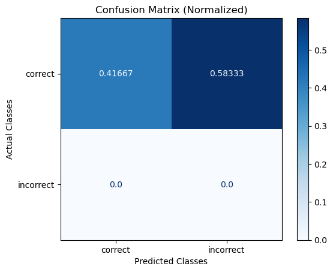

```python
true_labels = df_sample["answer_true"].map(QA_PROMPT_RAILS_MAP).tolist()

print(classification_report(true_labels, Q_and_A_classifications, labels=rails))
confusion_matrix = ConfusionMatrix(
    actual_vector=true_labels, predict_vector=Q_and_A_classifications, classes=rails
)
confusion_matrix.plot(
    cmap=plt.colormaps["Blues"],
    number_label=True,
    normalized=True,
)
```

```python
true_labels[:10]
```

[output not shown]

```python
true_labels[:10]
```

[output not shown]

```python
Q_and_A_classifications[:10]
```

```
['correct',
 'incorrect',
 'incorrect',
 'incorrect',
 'incorrect',
 'correct',
 'incorrect',
 'correct',
 'correct',
 'incorrect']
```

```python
df_sample['prediction']=Q_and_A_classifications
```

```python
df_sample['true_label']=true_labels
```

```python
df_sample['double_check']=0
df_sample.loc[df_sample.prediction!=df_sample.true_label, 'double_check']=1
```

```python
df_sample.double_check.value_counts()
```

[output not shown]

```python
df_sample[df_sample.double_check==1]
```

[output not shown]

```python
df_sample.to_csv('testing reg b_QA_chatgpt4_graded.csv')
```

### Testing 1 - answer_smt_chnk_regB_PdfTxt : incorrect: `0.4375`

```python
sampled_answer_to_test = ans_col_name[0]

df_sample = (
    df.sample(n=N_EVAL_SAMPLE_SIZE)
    .reset_index(drop=True)
    .rename(
        columns={
            "question": "input",
            "context": "reference",
            sampled_answer_to_test: "output", # change this
        }
    )
)
```

```python
print (ans_col_name[0])
```

```
answer_smt_chnk_regB_PdfTxt
```

```python
Q_and_A_classifications = llm_classify(
    dataframe=df_sample,
    template=QA_PROMPT_TEMPLATE,
    model=model,
    rails=list(QA_PROMPT_RAILS_MAP.values()),
    verbose= True,
    provide_explanation=True,
    concurrency=20,
)
```

[output not shown]

```
llm_classify |          | 0/96 (0.0%) | ⏳ 00:00<? | ?it/s
```

[output not shown]

[output cut: 46 more lines]

[output not shown]

```
              precision    recall  f1-score   support

     correct       1.00      0.56      0.72        96
   incorrect       0.00      0.00      0.00         0

    accuracy                           0.56        96
   macro avg       0.50      0.28      0.36        96
weighted avg       1.00      0.56      0.72        96
```

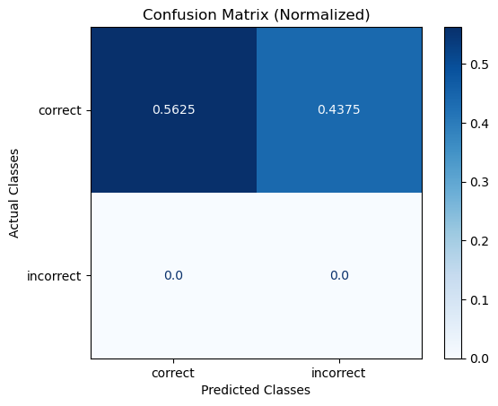

```python
true_labels = df_sample["answer_true"].map(QA_PROMPT_RAILS_MAP).tolist()
classes = list(QA_PROMPT_RAILS_MAP.values())

print(classification_report(true_labels, Q_and_A_classifications["label"].tolist(), labels=classes))
confusion_matrix = ConfusionMatrix(
    actual_vector=true_labels, predict_vector=Q_and_A_classifications["label"].tolist(), classes=classes
)
confusion_matrix.plot(
    cmap=plt.colormaps["Blues"],
    number_label=True,
    normalized=True,
)
```

```python
df_sample['prediction']=Q_and_A_classifications["label"].tolist()
df_sample['explanation']=Q_and_A_classifications["explanation"].tolist()
```

```python
# df_sample['true_label']=true_labels
```

```python
# df_sample['double_check']=0
# df_sample.loc[df_sample.prediction!=df_sample.true_label, 'double_check']=1
```

```python
# df_sample.double_check.value_counts()
```

```python
df_labeled = pd.read_csv('testing QA reg b_{}_gpt3.5_labeled.csv'.format(ans_col_name[0])).sort_values(by='#')[['#','MR_Checked_Answer']]
```

```python
df_sample=df_sample.sort_values(by='#').copy()
df_sample=pd.merge(df_sample,df_labeled, on='#')
# df_sample[df_sample.double_check==1]
# df_sample.drop(columns=['trule_label']).head()
df_sample.head()
```

|  | Unnamed: 0 | # | title | context.span_id | input | ground_truth | reference | answer_true_flag | answer_true | is_hallucination | ... | answer_nve_chnk_regB_PdfTxt | ref1_nve_chnk_regB_PdfTxt | ref2_nve_chnk_regB_PdfTxt | question_nve_chnk_regB_WebTxt | answer_nve_chnk_regB_WebTxt | ref1_nve_chnk_regB_WebTxt | ref2_nve_chnk_regB_WebTxt | prediction | explanation | MR_Checked_Answer |
| --- | --- | --- | --- | --- | --- | --- | --- | --- | --- | --- | --- | --- | --- | --- | --- | --- | --- | --- | --- | --- | --- |
| 0 | 0 | 1 | reg b | 5420b5dc5061d0b7 | How can a financial institution annualize the number of covered credit transactions it originates to small businesses from October 1 through December 31, 2023? | A financial institution can annualize the number of covered credit transactions it originates to small businesses from October 1 through December 31, 2023 by quadrupling the originations for this peri… | The financial institution may annualize the number of covered credit transactions it originates to small\nbusinesses from October 1 through December 31, 2023 by quadrupling the originations for this p… | 1 | True | NaN | ... | To annualize the number of covered credit transactions a financial institution originates to small businesses from October 1 through December 31, 2023, the institution should calculate the total numbe… | Step 7. Examiners should consult with their agency’s\nsupervisory staff if they see a need to contact control group\nor prohibited basis group applicants to substantiate the\nsteering analysis.\nF. Tr… | Additionally, consideration should be limited\nto factors which examiners determine to be legitimate.\nWhile the period for review should be 12-months, prohibited\nbasis group and control group borrow… | How can a financial institution annualize the number of covered credit transactions it originates to small businesses from October 1 through December 31, 2023? | To annualize the number of covered credit transactions a financial institution originates to small businesses from October 1 through December 31, 2023, the institution should calculate the total numbe… | Step 7. Examiners should consult with their agency’s\nsupervisory staff if they see a need to contact control group\nor prohibited basis group applicants to substantiate the\nsteering analysis.\nF. Tr… | Additionally, consideration should be limited\nto factors which examiners determine to be legitimate.\nWhile the period for review should be 12-months, prohibited\nbasis group and control group borrow… | correct | The answer correctly explains the process of annualizing the number of covered credit transactions a financial institution originates to small businesses from October 1 through December 31, 2023. It m… | Correct |
| 1 | 1 | 2 | reg b | ab727ae68cc856ac | What options does an applicant have if they want a statement of specific reasons for adverse action taken by a creditor within 60 days of notification? | The applicant has the option to request the statement of specific reasons for adverse action taken by the creditor in writing within 60 days of receiving the creditor's notification. | The disclosure shall include the name, address, and\ntelephone number of the person or office from which the statement of reasons can be obtained. If the creditor\nchooses to provide the reasons orall… | 1 | True | NaN | ... | An applicant has the option to request a statement of specific reasons for adverse action taken by a creditor within 60 days of notification. | c. How and when the policy or communication was put\ninto effect.\nd. How widely the policy or communication was applied.\ne. Whether and to what extent applicants were adversely\naffected by the poli… | Document all responses that have been provided\nby the institution, not just its “best” or “final” response.\nDocument each discussion with dates, names, titles,\nquestions, responses, any information… | What options does an applicant have if they want a statement of specific reasons for adverse action taken by a creditor within 60 days of notification? | An applicant has the option to request a statement of specific reasons for adverse action taken by a creditor within 60 days of notification. | c. How and when the policy or communication was put\ninto effect.\nd. How widely the policy or communication was applied.\ne. Whether and to what extent applicants were adversely\naffected by the poli… | Document all responses that have been provided\nby the institution, not just its “best” or “final” response.\nDocument each discussion with dates, names, titles,\nquestions, responses, any information… | correct | The answer correctly states that the applicant has the option to request a statement of specific reasons for adverse action taken by the creditor within 60 days of notification. This is in line with t… | Correct |
| 2 | 2 | 3 | reg b | 68bfeb197b24577d | What specific information about a financial institution's parent entity must be included in the submission? | The specific information about a financial institution's parent entity that must be included in the submission are the name of the immediate parent entity, the Legal Entity Identifier (LEI) of the imm… | (b) Financial institution identifying information. A financial institution shall provide each of the following with its submission:\n(1) Its name.\n(2) Its headquarters address.\n(3) The name and busi… | 1 | True | NaN | ... | Information regarding an affiliate or holding company subsidiary should be obtained directly from the institution itself. | Examples of terms and features include\nprepayment penalties and escrow requirements. The\ndistinction between a product, term, and feature may\nvary institution to institution. For example, some\nins… | This will help\nexaminers to recognize the potential scope of policybased violations.\n• The portfolio consists of applications from a purchased\ninstitution. If so, for scoping purposes, examiners\ns… | What specific information about a financial institution's parent entity must be included in the submission? | Information regarding an affiliate or holding company subsidiary should be obtained directly from the institution itself. | Examples of terms and features include\nprepayment penalties and escrow requirements. The\ndistinction between a product, term, and feature may\nvary institution to institution. For example, some\nins… | This will help\nexaminers to recognize the potential scope of policybased violations.\n• The portfolio consists of applications from a purchased\ninstitution. If so, for scoping purposes, examiners\ns… | incorrect | The answer provided does not specifically address the information about a financial institution's parent entity that must be included in the submission as outlined in the reference text. The reference… | Incorrect |
| 3 | 3 | 4 | reg b | 6e6673e2fb94d5eb | What are some examples of appropriate corrective actions that may be taken based on the results of a self-test for potential violations of the Equal Credit Opportunity Act? | Examples of appropriate corrective actions that may be taken based on the results of a self-test for potential violations of the Equal Credit Opportunity Act include offering to extend credit to indiv… | In\ndetermining whether it is more likely than not that a violation occurred, a creditor must treat testers as if they are actual applicants for\ncredit. A creditor may not refuse to take appropriate … | 1 | True | NaN | ... | Examples of appropriate corrective actions that may be taken based on the results of a self-test for potential violations of the Equal Credit Opportunity Act include providing additional training to s… | IV. Fair Lending — Fair Lending Laws and Regulations\nFDIC Consumer Compliance Examination Manual – March 2021 IV – 1.1\nFair Lending Laws and Regulations\nIntroduction\nThis overview provides a basic… | Document all responses that have been provided\nby the institution, not just its “best” or “final” response.\nDocument each discussion with dates, names, titles,\nquestions, responses, any information… | What are some examples of appropriate corrective actions that may be taken based on the results of a self-test for potential violations of the Equal Credit Opportunity Act? | Examples of appropriate corrective actions that may be taken based on the results of a self-test for potential violations of the Equal Credit Opportunity Act include providing additional training to s… | IV. Fair Lending — Fair Lending Laws and Regulations\nFDIC Consumer Compliance Examination Manual – March 2021 IV – 1.1\nFair Lending Laws and Regulations\nIntroduction\nThis overview provides a basic… | Document all responses that have been provided\nby the institution, not just its “best” or “final” response.\nDocument each discussion with dates, names, titles,\nquestions, responses, any information… | incorrect | To determine if the answer is correct, we need to compare the examples of appropriate corrective actions mentioned in the answer with the examples provided in the reference text. The reference text ou… | Incorrect |
| 4 | 4 | 5 | reg b | c50465abd93a6b24 | What does a financial institution report as the credit purpose if the applicant does not provide any information regarding the purpose of the credit? | The financial institution reports the credit purpose as "not provided by applicant and otherwise undetermined" if the applicant does not provide any information regarding the purpose of the credit. | If an application has more than three purposes, the financial institution reports any three of those purposes. In the example\nabove, if the funds were also used to purchase equipment, the financial i… | 1 | True | NaN | ... | The financial institution typically reports the credit purpose as "not available" if the applicant does not provide any information regarding the purpose of the credit. | This will help\nexaminers to recognize the potential scope of policybased violations.\n• The portfolio consists of applications from a purchased\ninstitution. If so, for scoping purposes, examiners\ns… | I. Credit Scoring.\nIf the scoping process results in the selection of a focal point\nthat includes a credit or mortgage scored loan product, refer\nto the Considering Automated Underwriting and Credi… | What does a financial institution report as the credit purpose if the applicant does not provide any information regarding the purpose of the credit? | The financial institution would report the credit purpose as "not available" if the applicant does not provide any information regarding the purpose of the credit. | I. Credit Scoring.\nIf the scoping process results in the selection of a focal point\nthat includes a credit or mortgage scored loan product, refer\nto the Considering Automated Underwriting and Credi… | This will help\nexaminers to recognize the potential scope of policybased violations.\n• The portfolio consists of applications from a purchased\ninstitution. If so, for scoping purposes, examiners\ns… | incorrect | The answer provided in the reference text states that if the applicant does not provide any information regarding the purpose of the credit, the financial institution reports the credit purpose as 'no… | Incorrect |

5 rows × 29 columns

```python
df_sample.to_csv('testing QA reg b_{}_gpt3.5_graded_labeled.csv'.format(ans_col_name[0]))
```

#### Some further examination

```python
df_labeled = pd.read_csv('testing QA reg b_{}_gpt3.5_graded_labeled.csv'.format(ans_col_name[0])).sort_values(by='#')
```

```python
df_labeled.head()
```

|  | Unnamed: 0.1 | Unnamed: 0 | # | title | context.span_id | input | ground_truth | reference | answer_true_flag | answer_true | ... | answer_nve_chnk_regB_PdfTxt | ref1_nve_chnk_regB_PdfTxt | ref2_nve_chnk_regB_PdfTxt | question_nve_chnk_regB_WebTxt | answer_nve_chnk_regB_WebTxt | ref1_nve_chnk_regB_WebTxt | ref2_nve_chnk_regB_WebTxt | prediction | explanation | MR_Checked_Answer |
| --- | --- | --- | --- | --- | --- | --- | --- | --- | --- | --- | --- | --- | --- | --- | --- | --- | --- | --- | --- | --- | --- |
| 0 | 0 | 0 | 1 | reg b | 5420b5dc5061d0b7 | How can a financial institution annualize the number of covered credit transactions it originates to small businesses from October 1 through December 31, 2023? | A financial institution can annualize the number of covered credit transactions it originates to small businesses from October 1 through December 31, 2023 by quadrupling the originations for this peri… | The financial institution may annualize the number of covered credit transactions it originates to small\nbusinesses from October 1 through December 31, 2023 by quadrupling the originations for this p… | 1 | True | ... | To annualize the number of covered credit transactions a financial institution originates to small businesses from October 1 through December 31, 2023, the institution should calculate the total numbe… | Step 7. Examiners should consult with their agency’s\nsupervisory staff if they see a need to contact control group\nor prohibited basis group applicants to substantiate the\nsteering analysis.\nF. Tr… | Additionally, consideration should be limited\nto factors which examiners determine to be legitimate.\nWhile the period for review should be 12-months, prohibited\nbasis group and control group borrow… | How can a financial institution annualize the number of covered credit transactions it originates to small businesses from October 1 through December 31, 2023? | To annualize the number of covered credit transactions a financial institution originates to small businesses from October 1 through December 31, 2023, the institution should calculate the total numbe… | Step 7. Examiners should consult with their agency’s\nsupervisory staff if they see a need to contact control group\nor prohibited basis group applicants to substantiate the\nsteering analysis.\nF. Tr… | Additionally, consideration should be limited\nto factors which examiners determine to be legitimate.\nWhile the period for review should be 12-months, prohibited\nbasis group and control group borrow… | correct | The answer correctly explains the process of annualizing the number of covered credit transactions a financial institution originates to small businesses from October 1 through December 31, 2023. It m… | Correct |
| 1 | 1 | 1 | 2 | reg b | ab727ae68cc856ac | What options does an applicant have if they want a statement of specific reasons for adverse action taken by a creditor within 60 days of notification? | The applicant has the option to request the statement of specific reasons for adverse action taken by the creditor in writing within 60 days of receiving the creditor's notification. | The disclosure shall include the name, address, and\ntelephone number of the person or office from which the statement of reasons can be obtained. If the creditor\nchooses to provide the reasons orall… | 1 | True | ... | An applicant has the option to request a statement of specific reasons for adverse action taken by a creditor within 60 days of notification. | c. How and when the policy or communication was put\ninto effect.\nd. How widely the policy or communication was applied.\ne. Whether and to what extent applicants were adversely\naffected by the poli… | Document all responses that have been provided\nby the institution, not just its “best” or “final” response.\nDocument each discussion with dates, names, titles,\nquestions, responses, any information… | What options does an applicant have if they want a statement of specific reasons for adverse action taken by a creditor within 60 days of notification? | An applicant has the option to request a statement of specific reasons for adverse action taken by a creditor within 60 days of notification. | c. How and when the policy or communication was put\ninto effect.\nd. How widely the policy or communication was applied.\ne. Whether and to what extent applicants were adversely\naffected by the poli… | Document all responses that have been provided\nby the institution, not just its “best” or “final” response.\nDocument each discussion with dates, names, titles,\nquestions, responses, any information… | correct | The answer correctly states that the applicant has the option to request a statement of specific reasons for adverse action taken by the creditor within 60 days of notification. This is in line with t… | Correct |
| 2 | 2 | 2 | 3 | reg b | 68bfeb197b24577d | What specific information about a financial institution's parent entity must be included in the submission? | The specific information about a financial institution's parent entity that must be included in the submission are the name of the immediate parent entity, the Legal Entity Identifier (LEI) of the imm… | (b) Financial institution identifying information. A financial institution shall provide each of the following with its submission:\n(1) Its name.\n(2) Its headquarters address.\n(3) The name and busi… | 1 | True | ... | Information regarding an affiliate or holding company subsidiary should be obtained directly from the institution itself. | Examples of terms and features include\nprepayment penalties and escrow requirements. The\ndistinction between a product, term, and feature may\nvary institution to institution. For example, some\nins… | This will help\nexaminers to recognize the potential scope of policybased violations.\n• The portfolio consists of applications from a purchased\ninstitution. If so, for scoping purposes, examiners\ns… | What specific information about a financial institution's parent entity must be included in the submission? | Information regarding an affiliate or holding company subsidiary should be obtained directly from the institution itself. | Examples of terms and features include\nprepayment penalties and escrow requirements. The\ndistinction between a product, term, and feature may\nvary institution to institution. For example, some\nins… | This will help\nexaminers to recognize the potential scope of policybased violations.\n• The portfolio consists of applications from a purchased\ninstitution. If so, for scoping purposes, examiners\ns… | incorrect | The answer provided does not specifically address the information about a financial institution's parent entity that must be included in the submission as outlined in the reference text. The reference… | Incorrect |
| 3 | 3 | 3 | 4 | reg b | 6e6673e2fb94d5eb | What are some examples of appropriate corrective actions that may be taken based on the results of a self-test for potential violations of the Equal Credit Opportunity Act? | Examples of appropriate corrective actions that may be taken based on the results of a self-test for potential violations of the Equal Credit Opportunity Act include offering to extend credit to indiv… | In\ndetermining whether it is more likely than not that a violation occurred, a creditor must treat testers as if they are actual applicants for\ncredit. A creditor may not refuse to take appropriate … | 1 | True | ... | Examples of appropriate corrective actions that may be taken based on the results of a self-test for potential violations of the Equal Credit Opportunity Act include providing additional training to s… | IV. Fair Lending — Fair Lending Laws and Regulations\nFDIC Consumer Compliance Examination Manual – March 2021 IV – 1.1\nFair Lending Laws and Regulations\nIntroduction\nThis overview provides a basic… | Document all responses that have been provided\nby the institution, not just its “best” or “final” response.\nDocument each discussion with dates, names, titles,\nquestions, responses, any information… | What are some examples of appropriate corrective actions that may be taken based on the results of a self-test for potential violations of the Equal Credit Opportunity Act? | Examples of appropriate corrective actions that may be taken based on the results of a self-test for potential violations of the Equal Credit Opportunity Act include providing additional training to s… | IV. Fair Lending — Fair Lending Laws and Regulations\nFDIC Consumer Compliance Examination Manual – March 2021 IV – 1.1\nFair Lending Laws and Regulations\nIntroduction\nThis overview provides a basic… | Document all responses that have been provided\nby the institution, not just its “best” or “final” response.\nDocument each discussion with dates, names, titles,\nquestions, responses, any information… | incorrect | To determine if the answer is correct, we need to compare the examples of appropriate corrective actions mentioned in the answer with the examples provided in the reference text. The reference text ou… | Incorrect |
| 4 | 4 | 4 | 5 | reg b | c50465abd93a6b24 | What does a financial institution report as the credit purpose if the applicant does not provide any information regarding the purpose of the credit? | The financial institution reports the credit purpose as "not provided by applicant and otherwise undetermined" if the applicant does not provide any information regarding the purpose of the credit. | If an application has more than three purposes, the financial institution reports any three of those purposes. In the example\nabove, if the funds were also used to purchase equipment, the financial i… | 1 | True | ... | The financial institution typically reports the credit purpose as "not available" if the applicant does not provide any information regarding the purpose of the credit. | This will help\nexaminers to recognize the potential scope of policybased violations.\n• The portfolio consists of applications from a purchased\ninstitution. If so, for scoping purposes, examiners\ns… | I. Credit Scoring.\nIf the scoping process results in the selection of a focal point\nthat includes a credit or mortgage scored loan product, refer\nto the Considering Automated Underwriting and Credi… | What does a financial institution report as the credit purpose if the applicant does not provide any information regarding the purpose of the credit? | The financial institution would report the credit purpose as "not available" if the applicant does not provide any information regarding the purpose of the credit. | I. Credit Scoring.\nIf the scoping process results in the selection of a focal point\nthat includes a credit or mortgage scored loan product, refer\nto the Considering Automated Underwriting and Credi… | This will help\nexaminers to recognize the potential scope of policybased violations.\n• The portfolio consists of applications from a purchased\ninstitution. If so, for scoping purposes, examiners\ns… | incorrect | The answer provided in the reference text states that if the applicant does not provide any information regarding the purpose of the credit, the financial institution reports the credit purpose as 'no… | Incorrect |

5 rows × 30 columns

### MR Mannually Checked Samples

```python
df_labeled.MR_Checked_Answer.value_counts(normalize=True)
```

```
Correct      0.5
Incorrect    0.5
Name: MR_Checked_Answer, dtype: float64
```

### Incorrect Rate

```python
df_labeled.prediction.value_counts(normalize=True).reset_index()
```

|  | index | prediction |
| --- | --- | --- |
| 0 | correct | 0.5625 |
| 1 | incorrect | 0.4375 |

### Testing 2 - answer_smt_chnk_regB_WebTxt : incorrect: `0.46875`

```python
sampled_answer_to_test = ans_col_name[1]

df_sample = (
    df.sample(n=N_EVAL_SAMPLE_SIZE)
    .reset_index(drop=True)
    .rename(
        columns={
            "question": "input",
            "context": "reference",
            sampled_answer_to_test: "output", # change this
        }
    )
)
```

```python
print (ans_col_name[1])
```

```
answer_smt_chnk_regB_WebTxt
```

```python
Q_and_A_classifications = llm_classify(
    dataframe=df_sample,
    template=QA_PROMPT_TEMPLATE,
    model=model,
    rails=list(QA_PROMPT_RAILS_MAP.values()),
    verbose= True,
    provide_explanation=True,
    concurrency=20,
)
```

```
Using prompt:


You are given a question, an answer and reference text. You must determine whether the
given answer correctly answers the question based on the reference text. Here is the data:
    [BEGIN DATA]
    ************
    [Question]: {input}
    ************
    [Reference]: {reference}
    ************
    [Answer]: {output}
    [END DATA]
Please read the query, reference text and answer carefully, then write out in a step by step manner
an EXPLANATION to show how to determine if the answer is "correct" or "incorrect". Avoid simply
stating the correct answer at the outset. Your response LABEL must be a single word, either
"correct" or "incorrect", and should not contain any text or characters aside from that word.
"correct" means that the question is correctly and fully answered by the answer.
"incorrect" means that the question is not correctly or only partially answered by the
answer.

Example response:
************
EXPLANATION: An explanation of your reasoning for why the label is "correct" or "incorrect"
LABEL: "correct" or "incorrect"
************

EXPLANATION:
OpenAI invocation parameters: {'model': 'gpt-3.5-turbo', 'temperature': 0.0, 'max_tokens': 256, 'frequency_penalty': 0, 'presence_penalty': 0, 'top_p': 1, 'n': 1, 'timeout': 20}
```

```
llm_classify |          | 0/96 (0.0%) | ⏳ 00:00<? | ?it/s
```

[output not shown]

[output cut: 45 more lines]

[output not shown]

```
              precision    recall  f1-score   support

     correct       1.00      0.53      0.69        96
   incorrect       0.00      0.00      0.00         0

    accuracy                           0.53        96
   macro avg       0.50      0.27      0.35        96
weighted avg       1.00      0.53      0.69        96
```

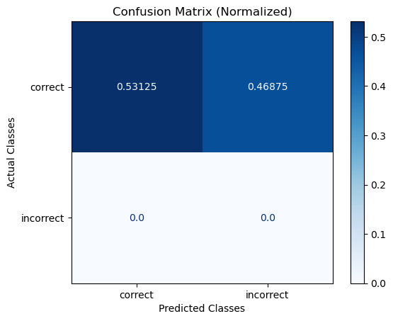

```python
true_labels = df_sample["answer_true"].map(QA_PROMPT_RAILS_MAP).tolist()
classes = list(QA_PROMPT_RAILS_MAP.values())

print(classification_report(true_labels, Q_and_A_classifications["label"].tolist(), labels=classes))
confusion_matrix = ConfusionMatrix(
    actual_vector=true_labels, predict_vector=Q_and_A_classifications["label"].tolist(), classes=classes
)
confusion_matrix.plot(
    cmap=plt.colormaps["Blues"],
    number_label=True,
    normalized=True,
)
```

```python
df_sample['prediction']=Q_and_A_classifications["label"].tolist()
df_sample['explanation']=Q_and_A_classifications["explanation"].tolist()
```

```python
# df_sample['true_label']=true_labels
```

```python
# df_sample['double_check']=0
# df_sample.loc[df_sample.prediction!=df_sample.true_label, 'double_check']=1
```

```python
# df_sample.double_check.value_counts()
```

```python
# df_labeled = pd.read_csv('testing QA reg b_{}_gpt3.5_labeled.csv'.format(ans_col_name[0])).sort_values(by='#')[['#','MR_Checked_Answer']]
```

```python
# df_sample=df_sample.sort_values(by='#').copy()
# df_sample=pd.merge(df_sample,df_labeled, on='#')
# # df_sample[df_sample.double_check==1]
# # df_sample.drop(columns=['trule_label']).head()
# df_sample.head()
```

```python
df_sample.head()
```

|  | Unnamed: 0 | # | title | context.span_id | input | ground_truth | reference | answer_true_flag | answer_true | is_hallucination | ... | question_nve_chnk_regB_PdfTxt | answer_nve_chnk_regB_PdfTxt | ref1_nve_chnk_regB_PdfTxt | ref2_nve_chnk_regB_PdfTxt | question_nve_chnk_regB_WebTxt | answer_nve_chnk_regB_WebTxt | ref1_nve_chnk_regB_WebTxt | ref2_nve_chnk_regB_WebTxt | prediction | explanation |
| --- | --- | --- | --- | --- | --- | --- | --- | --- | --- | --- | --- | --- | --- | --- | --- | --- | --- | --- | --- | --- | --- |
| 0 | 69 | 70 | reg b | 3e5c32fdcecf1931 | What are the key factors that adversely affected the applicant's credit score? | Insufficient bank references, type of occupation, insufficient credit experience, and number of recent inquiries on credit bureau report were the key factors that adversely affected the applicant's cr… | A creditor need not describe how or why a factor adversely affected an applicant. For example, the\nnotice may say “length of residence” rather than “too short a period of residence.”\n4. Credit scori… | 1 | True | NaN | ... | What are the key factors that adversely affected the applicant's credit score? | Factors that adversely affected the applicant's credit score include a substantially higher proportion of withdrawn/incomplete applications from prohibited basis group applicants compared to other app… | U3. *Substantially higher proportion of withdrawn/\nincomplete applications from prohibited basis group\napplicants than from other applicants.\nU4. Vague or unduly subjective underwriting criteria.\n… | I. Credit Scoring.\nIf the scoping process results in the selection of a focal point\nthat includes a credit or mortgage scored loan product, refer\nto the Considering Automated Underwriting and Credi… | What are the key factors that adversely affected the applicant's credit score? | Factors that adversely affected the applicant's credit score include a substantially higher proportion of withdrawn/incomplete applications from prohibited basis group applicants compared to other app… | U3. *Substantially higher proportion of withdrawn/\nincomplete applications from prohibited basis group\napplicants than from other applicants.\nU4. Vague or unduly subjective underwriting criteria.\n… | I. Credit Scoring.\nIf the scoping process results in the selection of a focal point\nthat includes a credit or mortgage scored loan product, refer\nto the Considering Automated Underwriting and Credi… | correct | To determine if the answer is correct, we need to compare the key factors mentioned in the answer with the key factors that adversely affected the applicant's credit score as stated in the reference t… |
| 1 | 33 | 34 | reg b | ac797fd4745b8da6 | What rights does the applicant have under the Fair Credit Reporting Act regarding the information in their credit file? | The applicant has the right under the Fair Credit Reporting Act to request disclosure of the nature of any information that was used in making the credit decision, if the decision was based on informa… | The reporting agency played no part in our decision and is\nunable to supply specific reasons why we have denied credit to you. You also have a right to a free copy of your report from the\nreporting … | 1 | True | NaN | ... | What rights does the applicant have under the Fair Credit Reporting Act regarding the information in their credit file? | The applicant has the right under the Fair Credit Reporting Act to receive a copy of their credit report, dispute inaccurate or incomplete information, and have outdated information removed. They also… | IV. Fair Lending — Fair Lending Laws and Regulations\nFDIC Consumer Compliance Examination Manual – March 2021 IV – 1.1\nFair Lending Laws and Regulations\nIntroduction\nThis overview provides a basic… | IV. Fair Lending — Fair Lending Laws and Regulations\nFDIC Consumer Compliance Examination Manual – March 2021 IV – 1.25\ne. Telemarketers or predictive dialer programs\n• Learn how the institution id… | What rights does the applicant have under the Fair Credit Reporting Act regarding the information in their credit file? | The applicant has the right under the Fair Credit Reporting Act to obtain a copy of their credit report from a consumer reporting agency, dispute inaccurate or incomplete information in their credit f… | IV. Fair Lending — Fair Lending Laws and Regulations\nFDIC Consumer Compliance Examination Manual – March 2021 IV – 1.1\nFair Lending Laws and Regulations\nIntroduction\nThis overview provides a basic… | IV. Fair Lending — Fair Lending Laws and Regulations\nFDIC Consumer Compliance Examination Manual – March 2021 IV – 1.25\ne. Telemarketers or predictive dialer programs\n• Learn how the institution id… | correct | The answer correctly addresses the rights of the applicant under the Fair Credit Reporting Act as mentioned in the reference text. It mentions the right to receive a copy of the credit report, dispute… |
| 2 | 95 | 96 | reg b | dd62f8e020eb4966 | What are the appropriate notices that must be included in a creditor's form regarding the optional nature of courtesy titles, disclosure of alimony, child support, or separate maintenance, and limitat… | The appropriate notices that must be included in a creditor's form are those regarding the optional nature of courtesy titles, the option to disclose alimony, child support, or separate maintenance, a… | In any of these three instances, however, the appropriate notices\nregarding the optional nature of courtesy titles, the option to disclose alimony, child support, or separate maintenance, and\nthe li… | 1 | True | NaN | ... | What are the appropriate notices that must be included in a creditor's form regarding the optional nature of courtesy titles, disclosure of alimony, child support, or separate maintenance, and limitat… | The appropriate notices that must be included in a creditor's form regarding the optional nature of courtesy titles, disclosure of alimony, child support, or separate maintenance, and limitation conce… | Clarify what options are available to applicants\nThrough interviews with appropriate personnel of the\ninstitution and review of policy manuals, procedure\nguidelines and other directives, obtain and… | c. How and when the policy or communication was put\ninto effect.\nd. How widely the policy or communication was applied.\ne. Whether and to what extent applicants were adversely\naffected by the poli… | What are the appropriate notices that must be included in a creditor's form regarding the optional nature of courtesy titles, disclosure of alimony, child support, or separate maintenance, and limitat… | The appropriate notices that must be included in a creditor's form regarding the optional nature of courtesy titles, disclosure of alimony, child support, or separate maintenance, and limitation conce… | Clarify what options are available to applicants\nThrough interviews with appropriate personnel of the\ninstitution and review of policy manuals, procedure\nguidelines and other directives, obtain and… | c. How and when the policy or communication was put\ninto effect.\nd. How widely the policy or communication was applied.\ne. Whether and to what extent applicants were adversely\naffected by the poli… | correct | To determine if the answer is correct, we need to compare the provided answer with the information in the reference text. The answer correctly identifies the three key points that must be included in … |
| 3 | 74 | 75 | reg b | 7066026532730bbe | Explain the reporting procedure if a financial institution does not receive a response regarding an applicant's minority-owned, women-owned, and LGBTQI+-owned business statuses. | The financial institution reports that the applicant's business statuses were "not provided by applicant" if it does not receive a response regarding an applicant's minority-owned, women-owned, and LG… | If the financial institution uses a web-based data collection form, the form should be on its own page.\n6. Minority-owned, women-owned, and/or LGBTQI+-owned business statuses not provided by applican… | 1 | True | NaN | ... | Explain the reporting procedure if a financial institution does not receive a response regarding an applicant's minority-owned, women-owned, and LGBTQI+-owned business statuses. | The reporting procedure if a financial institution does not receive a response regarding an applicant's minority-owned, women-owned, and LGBTQI+-owned business statuses involves evaluating the mainten… | U3. *Substantially higher proportion of withdrawn/\nincomplete applications from prohibited basis group\napplicants than from other applicants.\nU4. Vague or unduly subjective underwriting criteria.\n… | Step 2. Conduct Comparative File Review\na. Select all (or a maximum of ten) denied applications that\nwere acted on during the three month period prior to the\nexamination. To the extent feasible, in… | Explain the reporting procedure if a financial institution does not receive a response regarding an applicant's minority-owned, women-owned, and LGBTQI+-owned business statuses. | The reporting procedure if a financial institution does not receive a response regarding an applicant's minority-owned, women-owned, and LGBTQI+-owned business statuses involves evaluating the mainten… | U3. *Substantially higher proportion of withdrawn/\nincomplete applications from prohibited basis group\napplicants than from other applicants.\nU4. Vague or unduly subjective underwriting criteria.\n… | Step 2. Conduct Comparative File Review\na. Select all (or a maximum of ten) denied applications that\nwere acted on during the three month period prior to the\nexamination. To the extent feasible, in… | incorrect | The answer provided does not directly address the reporting procedure if a financial institution does not receive a response regarding an applicant's minority-owned, women-owned, and LGBTQI+-owned bus… |
| 4 | 20 | 21 | reg b | dccb564184c75563 | What are the two prongs that a business must satisfy to be classified as a women-owned business under subpart B of the Equal Credit Opportunity Act? | The two prongs that a business must satisfy to be classified as a women-owned business under subpart B of the Equal Credit Opportunity Act are: \n1. One or more women must own or control more than 50 … | 2. Trustee. Although a trust is not considered a principal owner of a business for the purposes of subpart\nB, if the applicant for a covered credit transaction is a trust, a trustee is considered the… | 1 | True | NaN | ... | What are the two prongs that a business must satisfy to be classified as a women-owned business under subpart B of the Equal Credit Opportunity Act? | The two prongs that a business must satisfy to be classified as a women-owned business under subpart B of the Equal Credit Opportunity Act are that the business must be at least 51% owned by one or mo… | Step 7. Examiners should consult with their agency’s\nsupervisory staff if they see a need to contact control group\nor prohibited basis group applicants to substantiate the\nsteering analysis.\nF. Tr… | U3. *Substantially higher proportion of withdrawn/\nincomplete applications from prohibited basis group\napplicants than from other applicants.\nU4. Vague or unduly subjective underwriting criteria.\n… | What are the two prongs that a business must satisfy to be classified as a women-owned business under subpart B of the Equal Credit Opportunity Act? | The two prongs that a business must satisfy to be classified as a women-owned business under subpart B of the Equal Credit Opportunity Act are that the business must be at least 51% owned by one or mo… | Step 7. Examiners should consult with their agency’s\nsupervisory staff if they see a need to contact control group\nor prohibited basis group applicants to substantiate the\nsteering analysis.\nF. Tr… | U3. *Substantially higher proportion of withdrawn/\nincomplete applications from prohibited basis group\napplicants than from other applicants.\nU4. Vague or unduly subjective underwriting criteria.\n… | correct | The answer correctly identifies the two prongs that a business must satisfy to be classified as a women-owned business under subpart B of the Equal Credit Opportunity Act. The first prong is that the … |

5 rows × 28 columns

```python
df_sample.to_csv('testing QA reg b_{}_gpt3.5_graded.csv'.format(ans_col_name[1]))
```

```python
df_sample=pd.read_csv('testing QA reg b_{}_gpt3.5_graded.csv'.format(ans_col_name[1]))
```

### Incorrect Rate

```python
df_sample.prediction.value_counts(normalize=True).reset_index()
```

|  | index | prediction |
| --- | --- | --- |
| 0 | correct | 0.53125 |
| 1 | incorrect | 0.46875 |

### Testing 3 - answer_nve_chnk_regB_PdfTxt : incorrect: `0.46875`

```python
sampled_answer_to_test = ans_col_name[2]

df_sample = (
    df.sample(n=N_EVAL_SAMPLE_SIZE)
    .reset_index(drop=True)
    .rename(
        columns={
            "question": "input",
            "context": "reference",
            sampled_answer_to_test: "output", # change this
        }
    )
)
```

```python
print (ans_col_name[2])
```

```
answer_nve_chnk_regB_PdfTxt
```

```python
Q_and_A_classifications = llm_classify(
    dataframe=df_sample,
    template=QA_PROMPT_TEMPLATE,
    model=model,
    rails=list(QA_PROMPT_RAILS_MAP.values()),
    verbose= True,
    provide_explanation=True,
    concurrency=20,
)
```

```
Using prompt:


You are given a question, an answer and reference text. You must determine whether the
given answer correctly answers the question based on the reference text. Here is the data:
    [BEGIN DATA]
    ************
    [Question]: {input}
    ************
    [Reference]: {reference}
    ************
    [Answer]: {output}
    [END DATA]
Please read the query, reference text and answer carefully, then write out in a step by step manner
an EXPLANATION to show how to determine if the answer is "correct" or "incorrect". Avoid simply
stating the correct answer at the outset. Your response LABEL must be a single word, either
"correct" or "incorrect", and should not contain any text or characters aside from that word.
"correct" means that the question is correctly and fully answered by the answer.
"incorrect" means that the question is not correctly or only partially answered by the
answer.

Example response:
************
EXPLANATION: An explanation of your reasoning for why the label is "correct" or "incorrect"
LABEL: "correct" or "incorrect"
************

EXPLANATION:
OpenAI invocation parameters: {'model': 'gpt-3.5-turbo', 'temperature': 0.0, 'max_tokens': 256, 'frequency_penalty': 0, 'presence_penalty': 0, 'top_p': 1, 'n': 1, 'timeout': 20}
```

```
llm_classify |          | 0/96 (0.0%) | ⏳ 00:00<? | ?it/s
```

[output not shown]

[output cut: 45 more lines]

[output not shown]

```
              precision    recall  f1-score   support

     correct       1.00      0.53      0.69        96
   incorrect       0.00      0.00      0.00         0

    accuracy                           0.53        96
   macro avg       0.50      0.27      0.35        96
weighted avg       1.00      0.53      0.69        96
```

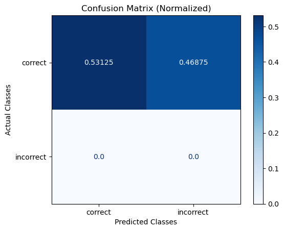

```python
true_labels = df_sample["answer_true"].map(QA_PROMPT_RAILS_MAP).tolist()
classes = list(QA_PROMPT_RAILS_MAP.values())

print(classification_report(true_labels, Q_and_A_classifications["label"].tolist(), labels=classes))
confusion_matrix = ConfusionMatrix(
    actual_vector=true_labels, predict_vector=Q_and_A_classifications["label"].tolist(), classes=classes
)
confusion_matrix.plot(
    cmap=plt.colormaps["Blues"],
    number_label=True,
    normalized=True,
)
```

```python
df_sample['prediction']=Q_and_A_classifications["label"].tolist()
df_sample['explanation']=Q_and_A_classifications["explanation"].tolist()
```

```python
# df_sample['true_label']=true_labels
```

```python
# df_sample['double_check']=0
# df_sample.loc[df_sample.prediction!=df_sample.true_label, 'double_check']=1
```

```python
# df_sample.double_check.value_counts()
```

```python
# df_labeled = pd.read_csv('testing QA reg b_{}_gpt3.5_labeled.csv'.format(ans_col_name[0])).sort_values(by='#')[['#','MR_Checked_Answer']]
```

```python
# df_sample=df_sample.sort_values(by='#').copy()
# df_sample=pd.merge(df_sample,df_labeled, on='#')
# # df_sample[df_sample.double_check==1]
# # df_sample.drop(columns=['trule_label']).head()
# df_sample.head()
```

```python
df_sample.to_csv('testing QA reg b_{}_gpt3.5_graded.csv'.format(ans_col_name[2]))
```

```python
df_sample=pd.read_csv('testing QA reg b_{}_gpt3.5_graded.csv'.format(ans_col_name[2]))
```

```python
df_sample.head()
```

|  | Unnamed: 0 | # | title | context.span_id | input | ground_truth | reference | answer_true_flag | answer_true | is_hallucination | ... | question_nve_chnk_regB_PdfTxt | output | ref1_nve_chnk_regB_PdfTxt | ref2_nve_chnk_regB_PdfTxt | question_nve_chnk_regB_WebTxt | answer_nve_chnk_regB_WebTxt | ref1_nve_chnk_regB_WebTxt | ref2_nve_chnk_regB_WebTxt | prediction | explanation |
| --- | --- | --- | --- | --- | --- | --- | --- | --- | --- | --- | --- | --- | --- | --- | --- | --- | --- | --- | --- | --- | --- |
| 0 | 16 | 17 | reg b | 25e0135a8a12a00a | In what situations can a creditor inquire about an applicant's marital status according to the regulations outlined in the document? | A creditor can inquire about an applicant's marital status if the applicant resides in a community property state or is relying on property located in such a state as a basis for repayment of the cred… | (3) Other accounts of the applicant. A creditor may request that an applicant list any account on which the applicant is\ncontractually liable and to provide the name and address of the person in whos… | 1 | True | NaN | ... | In what situations can a creditor inquire about an applicant's marital status according to the regulations outlined in the document? | In situations where the creditor needs to determine the applicant's ability to make payments, assess the applicant's creditworthiness, or comply with federal regulations related to the extension of cr… | c. How and when the policy or communication was put\ninto effect.\nd. How widely the policy or communication was applied.\ne. Whether and to what extent applicants were adversely\naffected by the poli… | U3. *Substantially higher proportion of withdrawn/\nincomplete applications from prohibited basis group\napplicants than from other applicants.\nU4. Vague or unduly subjective underwriting criteria.\n… | In what situations can a creditor inquire about an applicant's marital status according to the regulations outlined in the document? | A creditor can inquire about an applicant's marital status in situations where it is necessary for the extension of credit, such as when the applicant is relying on alimony, child support, or separate… | c. How and when the policy or communication was put\ninto effect.\nd. How widely the policy or communication was applied.\ne. Whether and to what extent applicants were adversely\naffected by the poli… | U3. *Substantially higher proportion of withdrawn/\nincomplete applications from prohibited basis group\napplicants than from other applicants.\nU4. Vague or unduly subjective underwriting criteria.\n… | correct | The answer provided correctly addresses the situations in which a creditor can inquire about an applicant's marital status as outlined in the reference text. It mentions the need to determine the appl… |
| 1 | 35 | 36 | reg b | 855b35528704bf38 | In what ways can a creditor differentiate between different sources of earned income when assessing an applicant's creditworthiness? | A creditor can differentiate between different sources of earned income when assessing an applicant's creditworthiness by scoring or treating earned income from a secondary source differently than ear… | 3. Consideration of income.\ni. A creditor need not consider income at all in evaluating creditworthiness. If a creditor does consider income,\nthere are several acceptable methods, whether in a credi… | 1 | True | NaN | ... | In what ways can a creditor differentiate between different sources of earned income when assessing an applicant's creditworthiness? | A creditor can differentiate between different sources of earned income when assessing an applicant's creditworthiness by considering factors such as stability, consistency, and predictability of the … | Step 2. Conduct Comparative File Review\na. Select all (or a maximum of ten) denied applications that\nwere acted on during the three month period prior to the\nexamination. To the extent feasible, in… | Step 7. Examiners should consult with their agency’s\nsupervisory staff if they see a need to contact control group\nor prohibited basis group applicants to substantiate the\nsteering analysis.\nF. Tr… | In what ways can a creditor differentiate between different sources of earned income when assessing an applicant's creditworthiness? | A creditor can differentiate between different sources of earned income when assessing an applicant's creditworthiness by considering factors such as stability, consistency, and predictability of the … | Step 2. Conduct Comparative File Review\na. Select all (or a maximum of ten) denied applications that\nwere acted on during the three month period prior to the\nexamination. To the extent feasible, in… | Step 7. Examiners should consult with their agency’s\nsupervisory staff if they see a need to contact control group\nor prohibited basis group applicants to substantiate the\nsteering analysis.\nF. Tr… | correct | The answer provided correctly explains how a creditor can differentiate between different sources of earned income when assessing an applicant's creditworthiness. It mentions factors such as stability… |
| 2 | 41 | 42 | reg b | b47798c63e6f03ee | Define the term 'credit card' based on the information provided in the document. | A credit card is defined as any card, plate, coupon book, or other single credit device that may be used from time to time to obtain money, property, or services on credit. It excludes debit card acco… | The creditor shall exercise\nreasonable diligence in obtaining such information.\n(g) Business credit refers to extensions of credit primarily for business or commercial (including agricultural) purpo… | 1 | True | NaN | ... | Define the term 'credit card' based on the information provided in the document. | The term 'credit card' is not explicitly defined in the provided document. | I. Credit Scoring.\nIf the scoping process results in the selection of a focal point\nthat includes a credit or mortgage scored loan product, refer\nto the Considering Automated Underwriting and Credi… | Examples of terms and features include\nprepayment penalties and escrow requirements. The\ndistinction between a product, term, and feature may\nvary institution to institution. For example, some\nins… | Define the term 'credit card' based on the information provided in the document. | The term 'credit card' is not explicitly defined in the provided document. | I. Credit Scoring.\nIf the scoping process results in the selection of a focal point\nthat includes a credit or mortgage scored loan product, refer\nto the Considering Automated Underwriting and Credi… | Examples of terms and features include\nprepayment penalties and escrow requirements. The\ndistinction between a product, term, and feature may\nvary institution to institution. For example, some\nins… | incorrect | The answer provided states that the term 'credit card' is not explicitly defined in the document. To determine if this answer is correct, we need to refer to the information provided in the reference … |
| 3 | 49 | 50 | reg b | eefa01af26988cf9 | How does the concept of agents come into play when reporting covered applications in the context of financial institutions? | When a covered financial institution takes action on a covered application through its agent, the financial institution reports the application. For instance, if Financial Institution A's agent, Finan… | Financial Institution A received a covered application and forwarded it to Financial Institutions B, C, and D. Financial\nInstitution A was not acting as anyone's agent. Financial Institution B and C … | 1 | True | NaN | ... | How does the concept of agents come into play when reporting covered applications in the context of financial institutions? | The concept of agents comes into play when reporting covered applications in the context of financial institutions by considering any third parties, such as brokers or contractors, involved in the cre… | This will help\nexaminers to recognize the potential scope of policybased violations.\n• The portfolio consists of applications from a purchased\ninstitution. If so, for scoping purposes, examiners\ns… | Examples of terms and features include\nprepayment penalties and escrow requirements. The\ndistinction between a product, term, and feature may\nvary institution to institution. For example, some\nins… | How does the concept of agents come into play when reporting covered applications in the context of financial institutions? | The concept of agents comes into play when reporting covered applications in the context of financial institutions by considering any third parties, such as brokers or contractors, involved in the cre… | This will help\nexaminers to recognize the potential scope of policybased violations.\n• The portfolio consists of applications from a purchased\ninstitution. If so, for scoping purposes, examiners\ns… | Examples of terms and features include\nprepayment penalties and escrow requirements. The\ndistinction between a product, term, and feature may\nvary institution to institution. For example, some\nins… | incorrect | The answer provided does not directly address the concept of agents in the context of reporting covered applications in financial institutions. It focuses more on fair lending compliance and the invol… |
| 4 | 43 | 44 | reg b | 052fb9805c3afb10 | What is the significance of the compliance date specified in § 1002.114(b) for covered financial institutions? | The compliance date specified in § 1002.114(b) determines when covered financial institutions must begin compiling data, comply with firewall requirements, and maintain records as per the regulations.… | The financial institution must compile data for this period pursuant to § 1002.107, comply with\nthe firewall requirements of § 1002.108, and maintain records as specified in § 1002.111. In addition, … | 1 | True | NaN | ... | What is the significance of the compliance date specified in § 1002.114(b) for covered financial institutions? | The compliance date specified in § 1002.114(b) for covered financial institutions is significant because it marks the deadline by which these institutions must comply with the requirements related to … | Overall institution compliance record is weak.\nC2. Prohibited basis monitoring information required by\napplicable laws and regulations is nonexistent or\nincomplete.\nC3. Data and/or recordkeeping p… | • Records detailing policy exceptions or overrides,\nexception reporting and monitoring processes.\n• Copies of any consumer complaints alleging\ndiscrimination and related loan files.\n• Compliance p… | What is the significance of the compliance date specified in § 1002.114(b) for covered financial institutions? | The compliance date specified in § 1002.114(b) for covered financial institutions is important as it marks the deadline by which these institutions must comply with the requirements outlined in the re… | Overall institution compliance record is weak.\nC2. Prohibited basis monitoring information required by\napplicable laws and regulations is nonexistent or\nincomplete.\nC3. Data and/or recordkeeping p… | • Records detailing policy exceptions or overrides,\nexception reporting and monitoring processes.\n• Copies of any consumer complaints alleging\ndiscrimination and related loan files.\n• Compliance p… | correct | The answer correctly explains the significance of the compliance date specified in § 1002.114(b) for covered financial institutions. It mentions that the compliance date marks the deadline for institu… |

5 rows × 28 columns

### Incorrect Rate

```python
df_sample.prediction.value_counts(normalize=True).reset_index()
```

|  | index | prediction |
| --- | --- | --- |
| 0 | correct | 0.53125 |
| 1 | incorrect | 0.46875 |

### Testing 4 - answer_nve_chnk_regB_WebTxt : incorrect: `0.489583`

```python
sampled_answer_to_test = ans_col_name[3]

df_sample = (
    df.sample(n=N_EVAL_SAMPLE_SIZE)
    .reset_index(drop=True)
    .rename(
        columns={
            "question": "input",
            "context": "reference",
            sampled_answer_to_test: "output", # change this
        }
    )
)
```

```python
print (ans_col_name[3])
```

```
answer_nve_chnk_regB_WebTxt
```

```python
Q_and_A_classifications = llm_classify(
    dataframe=df_sample,
    template=QA_PROMPT_TEMPLATE,
    model=model,
    rails=list(QA_PROMPT_RAILS_MAP.values()),
    verbose= True,
    provide_explanation=True,
    concurrency=20,
)
```

```
Using prompt:


You are given a question, an answer and reference text. You must determine whether the
given answer correctly answers the question based on the reference text. Here is the data:
    [BEGIN DATA]
    ************
    [Question]: {input}
    ************
    [Reference]: {reference}
    ************
    [Answer]: {output}
    [END DATA]
Please read the query, reference text and answer carefully, then write out in a step by step manner
an EXPLANATION to show how to determine if the answer is "correct" or "incorrect". Avoid simply
stating the correct answer at the outset. Your response LABEL must be a single word, either
"correct" or "incorrect", and should not contain any text or characters aside from that word.
"correct" means that the question is correctly and fully answered by the answer.
"incorrect" means that the question is not correctly or only partially answered by the
answer.

Example response:
************
EXPLANATION: An explanation of your reasoning for why the label is "correct" or "incorrect"
LABEL: "correct" or "incorrect"
************

EXPLANATION:
OpenAI invocation parameters: {'model': 'gpt-3.5-turbo', 'temperature': 0.0, 'max_tokens': 256, 'frequency_penalty': 0, 'presence_penalty': 0, 'top_p': 1, 'n': 1, 'timeout': 20}
```

```
llm_classify |          | 0/96 (0.0%) | ⏳ 00:00<? | ?it/s
```

[output not shown]

[output cut: 45 more lines]

[output not shown]

```
              precision    recall  f1-score   support

     correct       1.00      0.51      0.68        96
   incorrect       0.00      0.00      0.00         0

    accuracy                           0.51        96
   macro avg       0.50      0.26      0.34        96
weighted avg       1.00      0.51      0.68        96
```

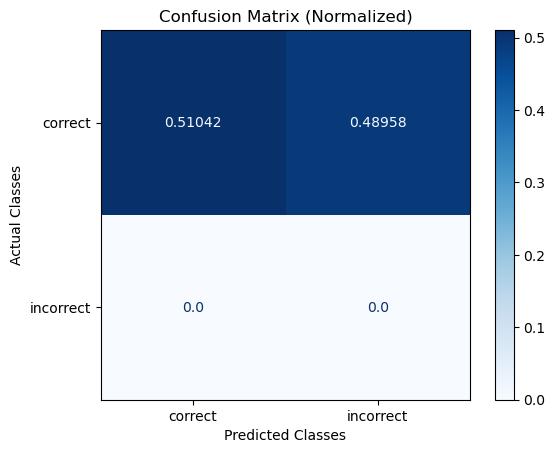

```python
true_labels = df_sample["answer_true"].map(QA_PROMPT_RAILS_MAP).tolist()
classes = list(QA_PROMPT_RAILS_MAP.values())

print(classification_report(true_labels, Q_and_A_classifications["label"].tolist(), labels=classes))
confusion_matrix = ConfusionMatrix(
    actual_vector=true_labels, predict_vector=Q_and_A_classifications["label"].tolist(), classes=classes
)
confusion_matrix.plot(
    cmap=plt.colormaps["Blues"],
    number_label=True,
    normalized=True,
)
```

```python
df_sample['prediction']=Q_and_A_classifications["label"].tolist()
df_sample['explanation']=Q_and_A_classifications["explanation"].tolist()
```

```python
# df_sample['true_label']=true_labels
```

```python
# df_sample['double_check']=0
# df_sample.loc[df_sample.prediction!=df_sample.true_label, 'double_check']=1
```

```python
# df_sample.double_check.value_counts()
```

```python
# df_labeled = pd.read_csv('testing QA reg b_{}_gpt3.5_labeled.csv'.format(ans_col_name[0])).sort_values(by='#')[['#','MR_Checked_Answer']]
```

```python
# df_sample=df_sample.sort_values(by='#').copy()
# df_sample=pd.merge(df_sample,df_labeled, on='#')
# # df_sample[df_sample.double_check==1]
# # df_sample.drop(columns=['trule_label']).head()
# df_sample.head()
```

```python
df_sample.to_csv('testing QA reg b_{}_gpt3.5_graded.csv'.format(ans_col_name[3]))
```

### Incorrect Rate

```python
df_sample=pd.read_csv('testing QA reg b_{}_gpt3.5_graded.csv'.format(ans_col_name[3]))
```

```python
df_sample.prediction.value_counts(normalize=True).reset_index()
```

|  | index | prediction |
| --- | --- | --- |
| 0 | correct | 0.510417 |
| 1 | incorrect | 0.489583 |

## SKIPPING

```python
model = OpenAIModel(model="gpt-4-turbo-preview", temperature=0.0)
```

```python
Q_and_A_classifications = llm_classify(
    dataframe=df_sample,
    template=QA_PROMPT_TEMPLATE,
    model=model,
    rails=list(QA_PROMPT_RAILS_MAP.values()),
    concurrency=20,
)["label"].tolist()
```

[output not shown]

[output not shown]

[figure not shown]

```python
true_labels = df_sample["answer_true"].map(QA_PROMPT_RAILS_MAP).tolist()
classes = list(QA_PROMPT_RAILS_MAP.values())

print(classification_report(true_labels, Q_and_A_classifications, labels=classes))
confusion_matrix = ConfusionMatrix(
    actual_vector=true_labels, predict_vector=Q_and_A_classifications, classes=classes
)
confusion_matrix.plot(
    cmap=plt.colormaps["Blues"],
    number_label=True,
    normalized=True,
)
```